# Why Shiny

## Intro

[interactive chart not shown]

## Shiny Site Examples

Below are examples of what can be done in Shiny.

Police and Demand Planning Tool ([Click here to Open separately](https://gallery.shinyapps.io/TSupplyDemand/))

[interactive chart not shown]

A Shiny App to visualize and share a dog’s medical history. ([Click here to Open separately](https://jennadallen.shinyapps.io/pet-records-app/))  
[Github Code](https://github.com/jennaallen/dog_days/tree/master/pet-records-app)

[interactive chart not shown]

Real estate analytics, prediction modeling and forecasting for over 20,000 U.S. real estate markets. ([Click here to Open separately](https://jjames.shinyapps.io/shinyHome/))  
[Github Code](https://github.com/j2scode/shinyHome)

[interactive chart not shown]

## Starting to Build

### Let’s get started!

Task 1: Create the folder structure in your working directory as shown below.

[figure not shown]

Task 2: Create Shiny script and load Shiny library.

To create your first Shiny app you have **two** options:

1. Open a new script and insert the following:

```r
library(shiny)

ui <- fluidPage()

server <- function(input, output) {}

shinyApp(ui = ui, server = server)
```

2. While in your working directory (as created above), go to *File–> New File–> Shiny Web App*.This option will create a Shiny App in two scripts rather than one.

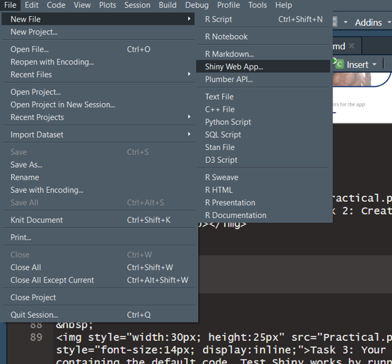

Task 3: Your app will be empty or will contain default code. Test Shiny works by running your app as shown below.

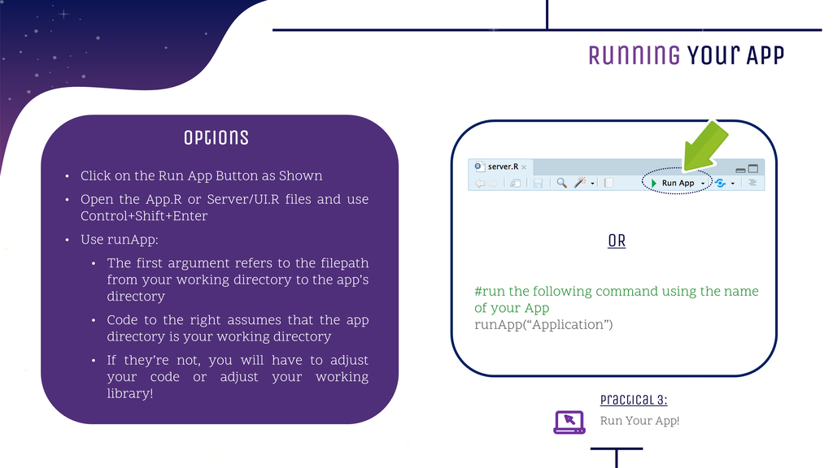

## Checkpoint 1

App Time

We will gradually build an app in steps today. Follow the brief below for your first step.

[interactive chart not shown]